# Notebook 2 - Greyscale

### Overview

This notebook is the modification of notebook 1 changing the source to a style more to my preference and readability.

Conversion to greyscale images isn't as simple as normalizing the RGB terms. We must take into account how our eyes function so that we get the colour's percieved intensity. We want greyscale because it's the stylistic preference that we're seeking. This reduction could help us reduce the amount of calculations as we could remove the redundant, completely similar, dimensions; however, this is not possible if we're using the CNN VGG16 as that network was trained on 3 colour values and not just 1 colour intensity value (The matrices sizes aren't compatible for multiplication).

The findings in this notebook will be taken into account when working on any future notebooks.

Here's the citation for original paper where the VGG16 network is described in detail:

Very Deep Convolutional Networks for Large-Scale Image Recognition, K. Simonyan, A. Zisserman, arXiv:1409.1556

#### Aside

I have also realized that setting up the underlying library, Tensorflow, to run using the GPU would increase productivity as I would have to wait less time just to generate an output, as of notebook 1 it has been using the CPU and producing a result takes just over 2 hours; which is too long.

### July 16th, 2017

Compressed code together cleaned it up and made it more readable. Renamed variables. Added greyscale conversions. Removed excessive output. Put all code in one cell for re-organization except for the stylized image saving code. In later notebooks it should not be expected to stay together all in one cell. Program also checks for what image extension and converts RGBA to RGB format.

#### Aside

The pillow image methods for converting an image to grayscale don't do exactly what we want. Since it changes the dimensions of the image to just a 2 dimensional array. We still want a 3 dimensional array for the VGG16 network. This is the reason for writing a greyscale conversion method instead of using a pre-exsiting one.

```
Start of iteration 0
Current loss value: 2.50792e+11
Iteration 0 completed in 717s
Start of iteration 1
Current loss value: 7.01416e+10
Iteration 1 completed in 702s
Start of iteration 2
Current loss value: 4.16095e+10
Iteration 2 completed in 709s
Start of iteration 3
Current loss value: 3.77215e+10
Iteration 3 completed in 711s
Start of iteration 4
Current loss value: 3.59548e+10
Iteration 4 completed in 713s
Start of iteration 5
Current loss value: 3.51391e+10
Iteration 5 completed in 709s
Start of iteration 6
Current loss value: 3.47404e+10
Iteration 6 completed in 709s
Start of iteration 7
Current loss value: 3.44757e+10
Iteration 7 completed in 709s
Start of iteration 8
Current loss value: 3.42988e+10
Iteration 8 completed in 716s
Start of iteration 9
Current loss value: 3.41858e+10
Iteration 9 completed in 708s
```

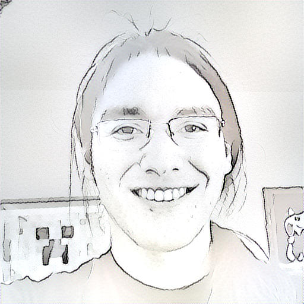

```python
# Dependecies
from __future__ import print_function
import os
import time
import numpy as np
from PIL import Image
from keras import backend as tf
from keras.models import Model
from keras.applications.vgg16 import VGG16
from scipy.optimize import fmin_l_bfgs_b
from scipy.misc import imsave

# Define the content loss function
def content_loss(content, combination):
    return tf.sum(tf.square(combination - content))

# Define the total variation loss, without this the image will come out noisy.
def total_variation_loss(x):
    a = tf.square(x[:, :height-1, :width-1, :] - x[:, 1:, :width-1, :])
    b = tf.square(x[:, :height-1, :width-1, :] - x[:, :height-1, 1:, :])
    return tf.sum(tf.pow(a + b, 1.25))

# Define the gram matrix
def gram_matrix(x):
    features = tf.batch_flatten(tf.permute_dimensions(x, (2, 0, 1)))
    gram = tf.dot(features, tf.transpose(features))
    return gram

# Defne the style loss functions
def style_loss(style, combination):
    S = gram_matrix(style)
    C = gram_matrix(combination)
    channels = 3
    size = height * width
    return tf.sum(tf.square(S - C)) / (4. * (channels ** 2) * (size ** 2))

# Define a method that calculates the loss and gradient
def eval_loss_and_grads(x):
    x = x.reshape((1, height, width, 3))
    outs = f_outputs([x])
    loss_value = outs[0]
    grad_values = outs[1].flatten().astype('float64')
    return loss_value, grad_values

# Convert to greyscale, but keep RGB so that it works with VGG16
def greyscale(image):
    img = Image.new("RGB", image.size, (255, 255, 255))
    xmax, ymax = image.size
    for y in range(ymax):
        for x in range(xmax):
            r, g, b = image.getpixel((x, y))
            p = int(0.2126*r + 0.7152*g + 0.0722*b)
            tuple = p, p, p
            img.putpixel((x, y), tuple)
    return img

# Object for L-BFGS method
class Evaluator(object):

    def __init__(self):
        self.loss_value = None
        self.grads_values = None

    def loss(self, x):
        assert self.loss_value is None
        loss_value, grad_values = eval_loss_and_grads(x)
        self.loss_value = loss_value
        self.grad_values = grad_values
        return self.loss_value

    def grads(self, x):
        assert self.loss_value is not None
        grad_values = np.copy(self.grad_values)
        self.loss_value = None
        self.grad_values = None
        return grad_values

#Set the desired size of the image
height = 512
width = 512

# base image directory path
image_path = 'images/'

# Load content reference image
content_image_filename = 'Sasha.png'
content_image_path = image_path + content_image_filename
tmp_content_image = Image.open(content_image_path)
tmp_content_image.load() # required for .split()

# Check if PNG of JPG, remove alpha if PNG.
content_ext = os.path.splitext(content_image_path)[1]
if(content_ext == '.png'):
    # Convert RBGA format to a simple RGB format
    tmp_content_image_split = tmp_content_image.split()
    if(len(tmp_content_image_split) == 4):
        content_image = Image.new("RGB", tmp_content_image.size, (255, 255, 255))
        content_image.paste(tmp_content_image, mask=tmp_content_image_split[3])
    else:
        content_image = tmp_content_image
elif(content_ext == '.jpg'):
    content_image = tmp_content_image
else:
    raise ValueError('Content image file must either be a JPG or a PNG file')

# Resize the Image
content_image = content_image.resize((height, width))

# Convert to greyscale
content_image = greyscale(content_image)
content_image

# Load the style reference image.
style_image_filename = 'Torean_bw.png'
style_image_path = image_path + style_image_filename
tmp_style_image = Image.open(style_image_path)
tmp_style_image.load() # required for .split()

# Check if PNG of JPG, remove alpha if PNG.
style_ext = os.path.splitext(style_image_path)[1]
if(style_ext == '.png'):
    # Convert RBGA format to a simple RGB format
    tmp_style_image_split = tmp_style_image.split()
    if(len(tmp_style_image_split) == 4):
        style_image = Image.new("RGB", tmp_style_image.size, (255, 255, 255))
        style_image.paste(tmp_style_image, mask=tmp_style_image_split[3])
    else:
        style_image = tmp_style_image
elif(style_ext == '.jpg'):
    style_image = tmp_style_image
else:
    raise ValueError('Style image file must either be a JPG or a PNG file')

# Resize the image
style_image = style_image.resize((height, width))

# Convert to geryscale
style_image = greyscale(style_image)
style_image

# Add an extra dimensions so that it can be used with VGG16
content_array = np.asarray(content_image, dtype='float32')
content_array = np.expand_dims(content_array, axis=0)
content_array.shape

style_array = np.asarray(style_image, dtype='float32')
style_array = np.expand_dims(style_array, axis=0)
style_array.shape

# Not sure, tweaking vals?
content_array[:, :, :, 0] -= 103.939
content_array[:, :, :, 1] -= 116.779
content_array[:, :, :, 2] -= 123.68
content_array = content_array[:, :, :, ::-1]

style_array[:, :, :, 0] -= 103.939
style_array[:, :, :, 1] -= 116.779
style_array[:, :, :, 2] -= 123.68
style_array = style_array[:, :, :, ::-1]

# Tensorflow variables
content_image = tf.variable(content_array)
style_image = tf.variable(style_array)
combination_image = tf.placeholder((1, height, width, 3))

# Create the input tensor for VGG16
input_tensor = tf.concatenate([content_image,
                                    style_image,
                                    combination_image], axis=0)

# Create the VGG16 model
model = VGG16(input_tensor=input_tensor, weights='imagenet',
              include_top=False)

# Create a dictionary for the layers from VGG16
layers = dict([(layer.name, layer.output) for layer in model.layers])

# Set how much content will be retained and how much style to transfer
content_weight = 0.025
style_weight = 5.0
total_variation_weight = 1.0

# Create the loss variable
loss = tf.variable(0.)

# Retrieve from our dictionary the layer for our content
layer_features = layers['block2_conv2']
content_image_features = layer_features[0, :, :, :]
combination_features = layer_features[2, :, :, :]

# Define the loss function using tensors
loss += content_weight * content_loss(content_image_features,
                                      combination_features)

# Retrieve from our dictionary the layers which we want to extract the style from.
# Style is better represented across layers not just in the highest abstracted one.
feature_layers = ['block1_conv2', 'block2_conv2',
                  'block3_conv3', 'block4_conv3',
                  'block5_conv3']

# Define the style loss funciton using tensors, must iterate because we need to do it for all layers.
for layer_name in feature_layers:
    layer_features = layers[layer_name]
    style_features = layer_features[1, :, :, :]
    combination_features = layer_features[2, :, :, :]
    sl = style_loss(style_features, combination_features)
    loss += (style_weight / len(feature_layers)) * sl

# Define it using tensors
loss += total_variation_weight * total_variation_loss(combination_image)

# Define the gradients
grads = tf.gradients(loss, combination_image)

# Define the outputs as the loss
outputs = [loss]
outputs += grads
f_outputs = tf.function([combination_image], outputs)

evaluator = Evaluator()

# Perform gradient decsent using L-BFGS
x = np.random.uniform(0, 255, (1, height, width, 3)) - 128.

iterations = 10

for i in range(iterations):
    print('Start of iteration', i)
    start_time = time.time()
    x, min_val, info = fmin_l_bfgs_b(evaluator.loss, x.flatten(),
                                     fprime=evaluator.grads, maxfun=20)
    print('Current loss value:', min_val)
    end_time = time.time()
    print('Iteration %d completed in %ds' % (i, end_time - start_time))

# Remove the extra bias dimension, re-adjust the RGB values and clip them.
x = x.reshape((height, width, 3))
x = x[:, :, ::-1]
x[:, :, 0] += 103.939
x[:, :, 1] += 116.779
x[:, :, 2] += 123.68
x = np.clip(x, 0, 255).astype('uint8')

# Output the image for viewing.
stylized_image = Image.fromarray(x)
stylized_image
```

```python
# Produce output filename
base = image_path + 'Notebook2'
content_part = os.path.splitext(content_image_filename)[0]
style_part = os.path.splitext(style_image_filename)[0]
ext = '.png'
filename = base + '_' + content_part + '_styled_as_' + style_part + ext
imsave(filename, x)
```

## July 17-18th, 2017 - Notebook Review

Sasha_styled_as_Alex_Sketch seemed to look only like a greyscale image, perhaps when the image resized the Alex_Sketch image lost some of the important details of what makes it look like a sketched image. So I tried a more rough sketch image of myself. The rough sketch Sasha_Sketch1.jpg did not prove to be any more better. For the last part of this notebook I tried the same images without converting them to greyscale to see if the conversion affected the output drasticaly. This didn't change the results; the images came out grey-ish colours of the originals.

I would speculate that this is because the details of the sketch-like style are too fine in detail or aren't represented enough in the stlye image or is reduce to near nothing when the resolution is reduced; however, it would be more appropriate to test this hypothesis in it's own notebook.

I will end this review changing the style reference image one last time, using an image that 'holds' more style than content. This is to get a better grasp of the level at which abstractions within the style reference image are taken.

# TODO:

Explore the posibility of creating a trained network to perform the stylistic transfer. This will be much faster as we can trim out the caculations we don't need to perform, significantly reducing computation. Or even perhaps exploring the different applications in Keras could help. Split source up into cells, mostly to check images before processing them.

## July 20th, 2017 - Cartoon Abstraction

It is easy to assume that some model exists to transform an image to it's 'cartoon' counterpart. In fact humans can easily do it; however, not all humans can do it and the ones that can do not do it the same way. Shows like The Simpsons and Family Guy have similar outline features, like in most animations, but it is not the only way to represent features. Even between the Simpsons and Family Guy it's only really the lower features that are represented in a similar fashion, the higher features are visually distinctive. Yet we can say that there is still a style, humans can perceive the differences and easily tell when a character is from the Simpsons or not, even if this characters is one they've never seen on the show.

To perform such a transformation, would we have to train a neural network how to draw real-world objects cartoon counter parts? What this notebook experimentation works on is style transfer, for cartoon style to be achieved a network would have to be train to transform the content of the content image; at which point is it even necessary to do style transfer using a style reference image? Possibly not.

#### Aside

I can't possibly be the only one who has thought of this. Google had some project where a computer would try and draw images like a human, but these images were too abstract and looked like the drawings of a 5 year old. Perhaps that's a starting point though.

I can imagine a loss function for optimization would be some combination of the loss between the animation style we'd want and the loss of it's real-world counter part, but then how do we measure loss then? Could we measure it by how much comparable and recongizable content there is? Is it possible to have a loss function based on how many items are in a scene? Or the amount of recognizable content similar to both images? I'll have to think about this more on my own time and focus on the work associated with these notebooks.

## July 21st - 23rd, 2017 - Playing around

During the past couple days I have been using images to try and see what features the CNN is good at abstracting and re-constructing.

## July 30th, 2017 - Comparing Style Outputs

By using the image Typho1.jpg, I have created similar images where the content is very similar, just the style is different. These images will be used to compare the variation in style output. As there are 4 images, this process will take around 8 hours with the current kernel setup for this notebook and the equipement being used.

Here's a table with the output images for the Typho images. It should be expected that the output images have variation in style.

[output not shown]

Here's some others where greyscale might have been used or not, if there's colour in the output image then no greyscale conversion was used.

[output not shown]

After studying the results, I have realized that just because the input is two greyscale images, the output doesn't have to be greyscale. This would explain the "red-ish" tinge in some of the output images. In which case it would probably make sense to only apply the greyscale conversion to the output image.

One final experiment...taking two outputs for new input. Not expecting big results, just interesting output.

[output not shown]

## August 8th, 2017

Cleaned up notebook content.